# Control yields revised 07/08/2023

Jackie Ouzman

07/08/2023

DF 1 is the control yields and treatment yields generated from the data supplied from database.

- splitting up the descriptors so they can be used as a filter this creates a number of new clm
- add yield gain clm

Note everything runs off of the rep specified in the raw data. I have run into problems with Younghusband, because the rep are not like the other sites. For the control the raw data has 4 yield results that are labelled rep 1.

This means that the ID (which is supposed to unique is not)

I have created a new rep which is the clm called bay number and the rep to create a rep_block so for the control I have how have rep block called Bay 1 rep 1 Bay 1 rep 2

Another problem with Younghusband is that they moved the control from year to year. As a result I have only included treatments that run over the two years, this means no control for this Younghusband data in the DB. We do have controls for each year but they cannot be put togther in the DB for multiple years.

….

Some sites are excluded from analysis - based on review by Mel and Therese

The next few steps is creating a df that splits up the descriptors into grouping

##### DF 1 - step 1 is the soil modification

##### DF 1 - step 2 is the amendments

Add code for amendments classed as

- animal
- plant
- non organic
- none
- mixed

## Scatter Plots control vs treatments yields **with amendment groupings**

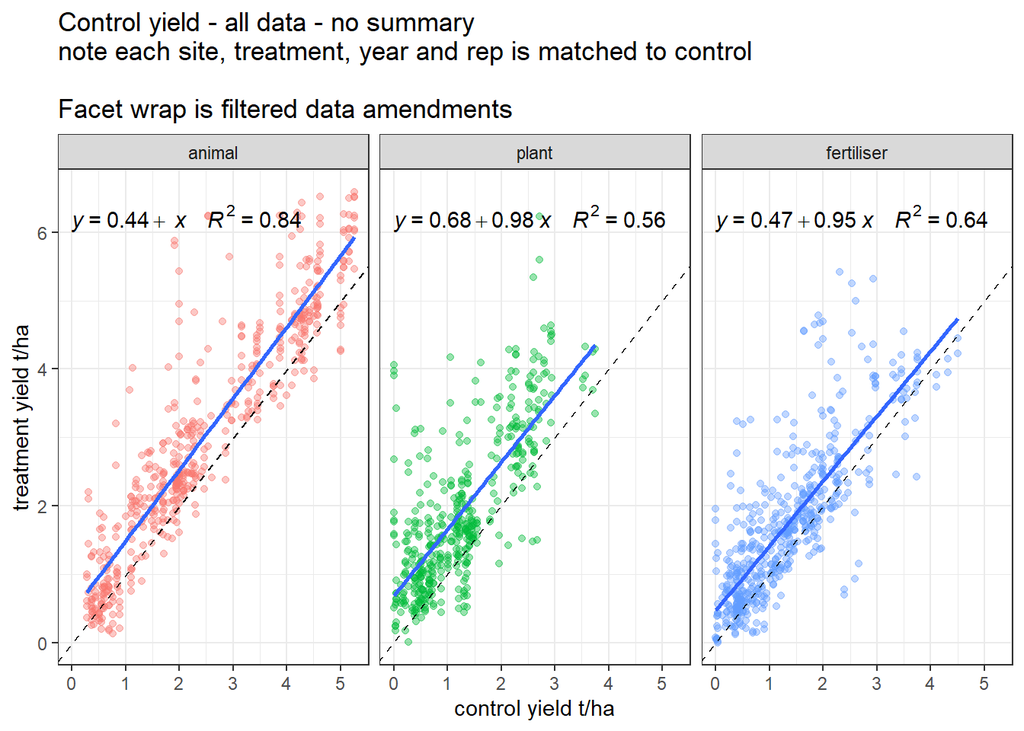

## what about when no soil modification was made?

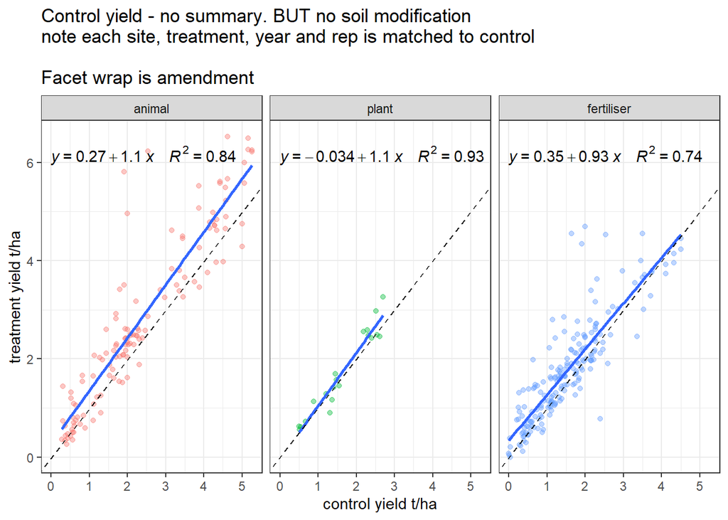

## what about when ANY soil modification was made?

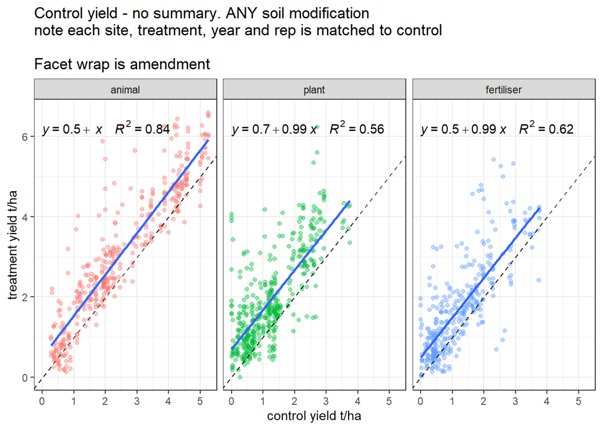

```
##  [1] "Kooloonong_lupin"     "Tempy"                "Wynarka"
##  [4] "Monia_Gap"            "Malinong"             "Sherwood"
##  [7] "Buckleboo"            "Mt Damper"            "Kybunga"
## [10] "Warnertown"           "Telopea_Downs"        "Brooker"
## [13] "Bute_CSIRO"           "Bute_Trengrove"       "Carwarp_Amelioration"
## [16] "Lowaldie_Crest"       "Lowaldie_Deep sand"   "Murlong"
## [19] "Brimpton Lake"        "Cadgee"               "Karoonda"
## [22] "Ouyen_Spade"          "Waikerie"             "Yenda"
## [25] "Younghusband"         "Ouyen_Placement"
```

```
## [1] "Unmodified+DeepTill.18_SE14.band_8" "Unmodified+DeepTill.18_none"
## [3] "Rip.50_none"                        "Spade.30_none"
## [5] "Rip.50IncRip_none"                  "Unmodified_SE14.band_8"
## [7] "Unmodified_Bi_Agra.surface+band_8"  "Unmodified+OnRow_none"
```